# PD5: eksperyment

Michalina Woźnica

2025-05-12

## Wstęp

Następnie należy przetestować na przynajmniej 15 innych osobach czy dany problem występuje, np. przeprowadzając ankietę typu czy lepszy jest wykres A czy B.

Celem pracy jest sprawdzenie czy ,,dobre praktyki’’ opracowane lata temu (słupki lepsze niż kąty, kolor wykorzystywany z umiarem, unikanie ozdobników), faktycznie działa w społeczeństwie, które wykresami karmione jest od urodzenia.

Celem eksperymentu było sprawdzenie, który z wykresów uczestnicy uznają za bardziej czytelny, łatwiejszy do interpretacji i dokładniejszy pod względem przedstawienia proporcji. Uczestnicy ankiety mieli wskazać, który z wykresów lepiej oddaje relacje pomiędzy kategoriami oraz co skłoniło ich do dokonania wyboru.

Danymi użytymi w eksperymencie była ramka danych , wbudowana w środowisko R. Zawiera ona informacje o ponad 50 tysiącach diamentów, w tym ich masa karatową, cenę, kolor, czystość i jakość szlifu. Oba wykresy przedtawiają liczbę diamentów w zależności od szlifu.

## Wykres Kołowy

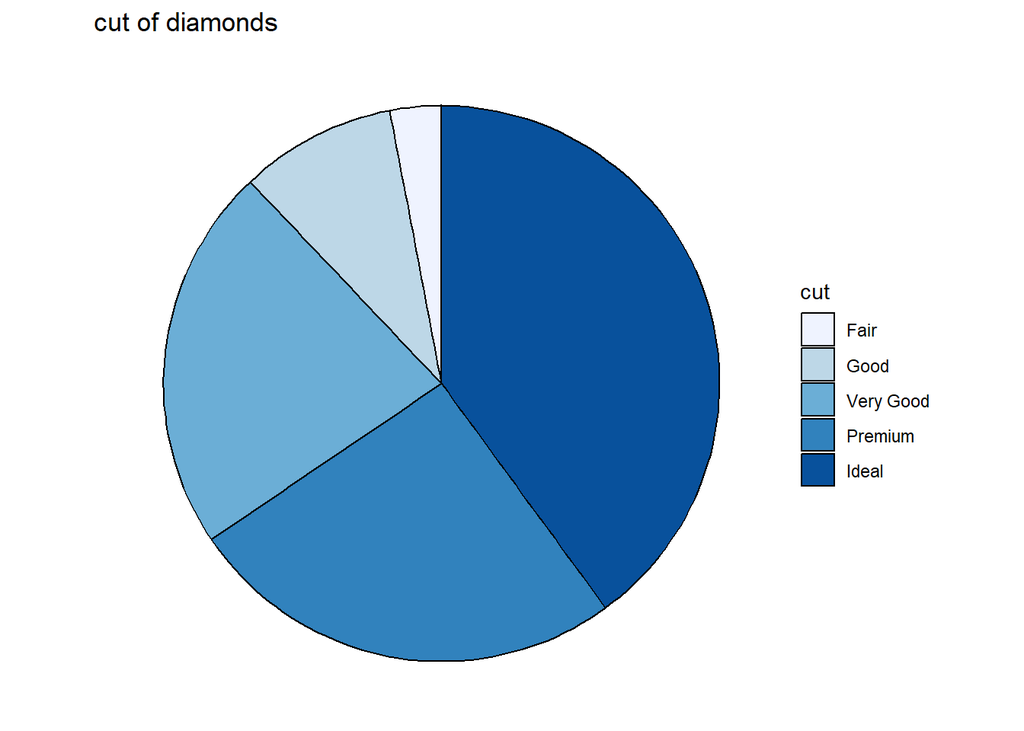

```r
diamonds %>%
  group_by(cut) %>%
  summarise(count = n()) %>%
  ggplot(aes(x = "", y = count, fill = cut))+
  geom_bar(stat = "identity", width = 1, color = "black") +
  coord_polar("y") +
  theme_void() +
  labs(title = "cut of diamonds")+
  scale_fill_brewer(palette = "Blues")
```

## Wykres słupkowy

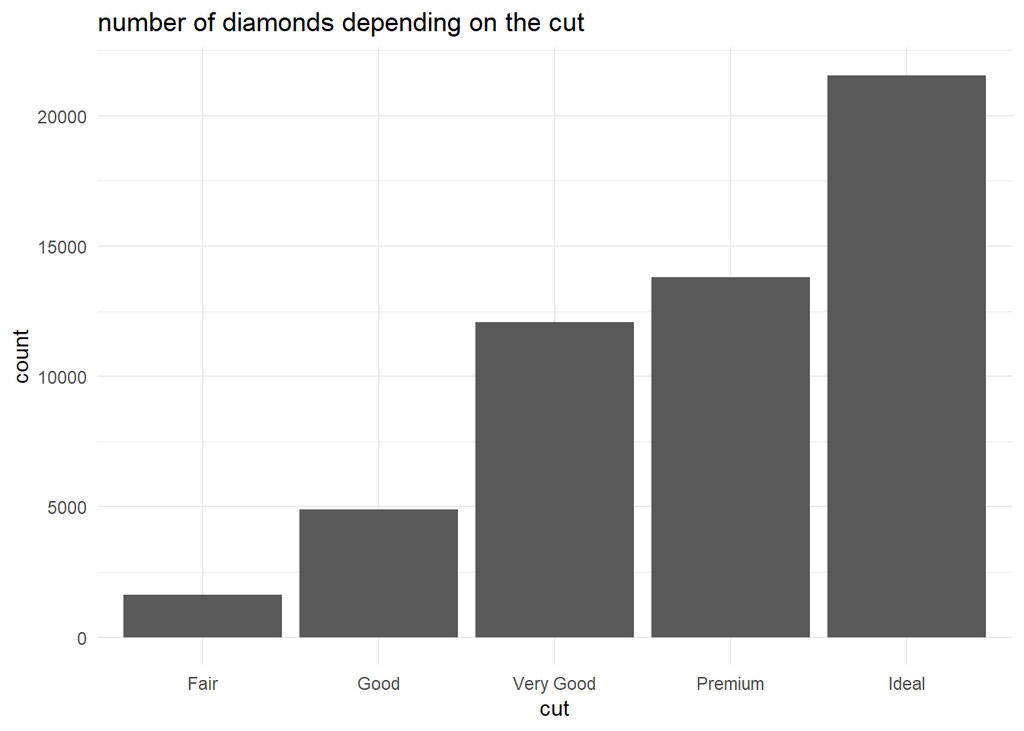

```r
ggplot(diamonds, aes(x = cut)) +
  geom_bar() +
  theme_minimal() +
  labs(title = "number of diamonds depending on the cut", x = "cut", y ="count")
```

## Wyniki eksperymentu

Z 17 uzyskanych odpowiedzi aż 10 osób zagłosowało za preferencją wykresu słupkowego. Najczęściej pojawiającymi się odpowiedziami na pytanie, dlaczego ankietowani dokonali takiego wyboru, były: czytelność, przejrzystość wykresu, lepsza interpretacja proporcji, a także łatwość porównania wartości między kategoriami.

Osoby opowiadające się za wykresem kołowym również wskzali czytelnośc wykresu jako głowną z przyczyn ich wyboru. Podkreślali, że wykres lepiej reprezentuje stosunki między szlifami, jest atrakcyjniejszy wizualnie , a odczyt informacji jest szybki i łatwiejszy w odbiorze dzięki użytym kolorom.

## Podsumowanie

Celem eksperymentu było zweryfikowanie, czy znane zasady wizualizacji danych, takie jak unikanie wykresów kołowych, ograniczanie liczby kolorów czy preferowanie wykresów słupkowych – są zgodne z rzeczywistym odbiorem społecznym. Z przeprowadzonego eksperymentu wynika, że większość ankietowanych wybiera minimalistyczy wykres słupkowy, uznając go za czytelniejszy i łatwiejszy w odbiorze. Jednocześnie duża część respondentów uznała wykres kołowy za lepszy w interpretacji i łatwiejszy w odczycie informacji.

Pomimo, że większość ankietowanych opowiedziała się za wykresem słupkowym, nie była to zdecydowana przewaga, ponieważ znaczna część ankietowanych uznała wykres kołowy za ich faworyta. Uzyskane wyniki potwierdzają, że zalecane praktyki w projektowaniu wykresów są nadal aktualne, choć jednocześnie sugerują, że odbiór wizulizacji danych danych mocno zależy również od preferencji, czy przyzwyczajeń.